# Lab5

Manin Egor Ri-450005

17 декабря 2018 г

# Загрузим данные

```r
data = read.csv("../data/diet.csv",row.names=1)
summary(data)
```

```
##      gender            Age            Height        pre.weight
##  Min.   :0.0000   Min.   :16.00   Min.   :141.0   Min.   : 58.00
##  1st Qu.:0.0000   1st Qu.:32.25   1st Qu.:164.2   1st Qu.: 66.00
##  Median :0.0000   Median :39.00   Median :169.5   Median : 72.00
##  Mean   :0.4342   Mean   :39.15   Mean   :170.8   Mean   : 72.53
##  3rd Qu.:1.0000   3rd Qu.:46.75   3rd Qu.:174.8   3rd Qu.: 78.00
##  Max.   :1.0000   Max.   :60.00   Max.   :201.0   Max.   :103.00
##  NA's   :2
##       Diet        weight6weeks
##  Min.   :1.000   Min.   : 53.00
##  1st Qu.:1.000   1st Qu.: 61.85
##  Median :2.000   Median : 68.95
##  Mean   :2.038   Mean   : 68.68
##  3rd Qu.:3.000   3rd Qu.: 73.83
##  Max.   :3.000   Max.   :103.00
##
```

## Ознакомимся со структурой и переименуем колонки

> [Diet data description](https://www.sheffield.ac.uk/polopoly_fs/1.547015!/file/Diet_data_description.docx), [Datasets for teaching](https://www.sheffield.ac.uk/mash/data).

```r
colnames(data) <- c("gender", "age", "height", "initial.weight",
                    "diet.type", "final.weight")
data$diet.type <- factor(c("A", "B", "C")[data$diet.type])
```

# Добавим новую колонку - Похудение

```r
data$weight.loss = data$initial.weight - data$final.weight
```

## Проанализиуем, есть ли различия по типам диет

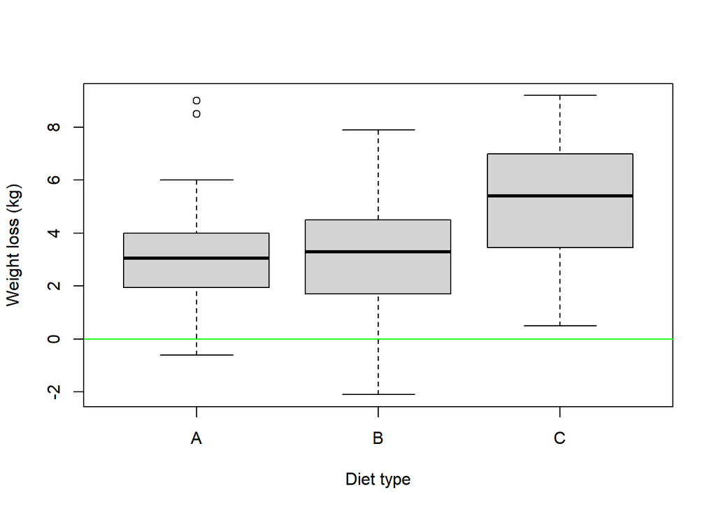

```r
boxplot(weight.loss~diet.type,data=data,col="light gray",
        ylab = "Weight loss (kg)", xlab = "Diet type")
abline(h=0,col="green")
```

## Проверим, сбалансированные ли данные

```r
table(data$diet.type)
```

```
##
##  A  B  C
## 24 27 27
```

## График групповых средних

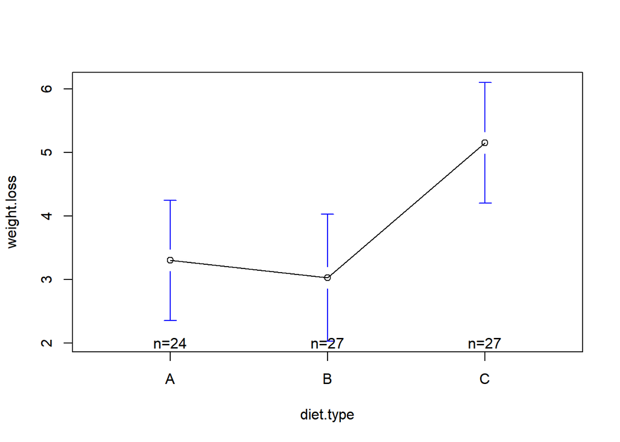

```r
plotmeans(weight.loss ~ diet.type, data=data)
```

```r
aggregate(data$weight.loss, by = list(data$diet.type), FUN=sd)
```

```
##   Group.1        x
## 1       A 2.240148
## 2       B 2.523367
## 3       C 2.395568
```

## Для подгонки ANOVA модели используем функцию aov, частный случай линейной модели lm тест на межгрупповые различия

```r
fit <- aov(weight.loss ~ diet.type, data=data)
summary(fit)
```

```
##             Df Sum Sq Mean Sq F value  Pr(>F)
## diet.type    2   71.1   35.55   6.197 0.00323 **
## Residuals   75  430.2    5.74
## ---
## Signif. codes:  0 '***' 0.001 '**' 0.01 '*' 0.05 '.' 0.1 ' ' 1
```

## Попарные различия между средними значениями для всех групп

```r
TukeyHSD(fit)
```

```
##   Tukey multiple comparisons of means
##     95% family-wise confidence level
##
## Fit: aov(formula = weight.loss ~ diet.type, data = data)
##
## $diet.type
##           diff        lwr      upr     p adj
## B-A -0.2740741 -1.8806155 1.332467 0.9124737
## C-A  1.8481481  0.2416067 3.454690 0.0201413
## C-B  2.1222222  0.5636481 3.680796 0.0047819
```

## Tukey honest significant differences test

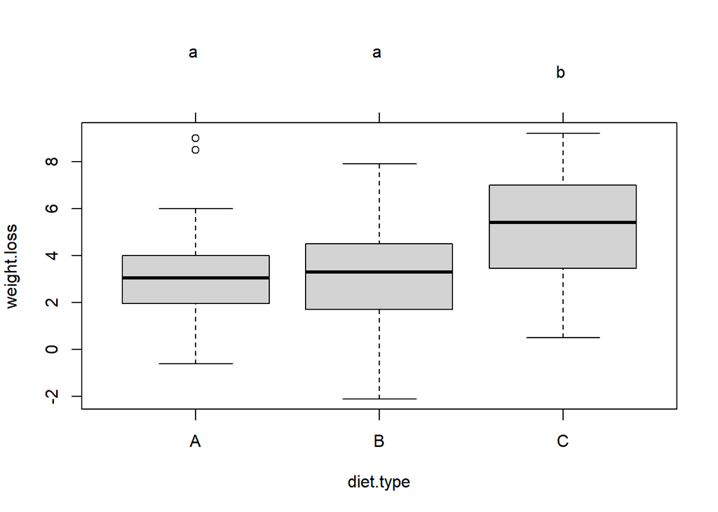

```r
par(mar=c(5,4,6,2))
tuk <- glht(fit, linfct=mcp(diet.type="Tukey"))
plot(cld(tuk, level=.05),col="lightgrey")
```

# Задание

> Добавить проверку на выборы и избавиться от них повторно проверсти все тесты и сравнить результаты с выбросами и без. Открыть [документ](https://www.sheffield.ac.uk/polopoly_fs/1.547015!/file/Diet_data_description.docx) и попытаться выполнить задания из него

Выясним, есть ли выбросы в имеющемся наборе данных

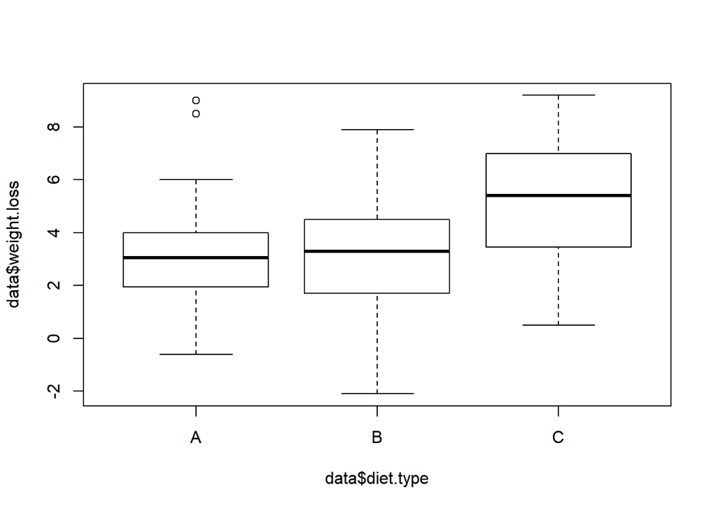

```r
plot(data$weight.loss ~ data$diet.type)
```

Очистим от значений >=8 && <=0

```r
data <- data %>%
  filter(weight.loss >= 0 & weight.loss <= 8)
```

Повторная проверка

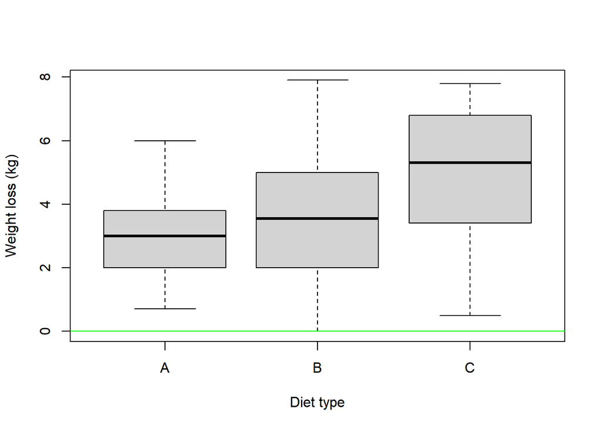

```r
boxplot(weight.loss~diet.type,data=data,col="light gray",
        ylab = "Weight loss (kg)", xlab = "Diet type")
abline(h=0,col="green")
```

Сбалансированность выборок

```r
table(data$diet.type)
```

```
##
##  A  B  C
## 21 24 25
```

График групповых средних

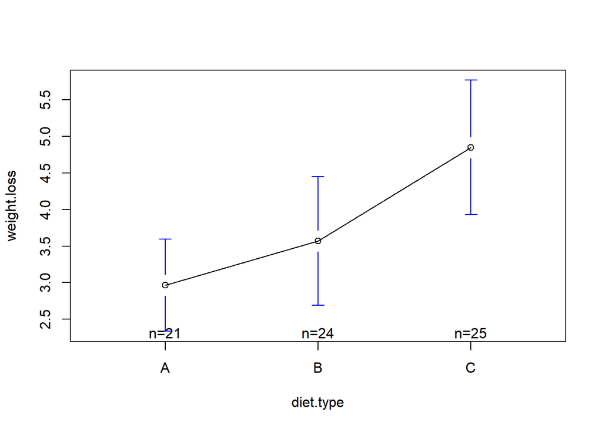

```r
plotmeans(weight.loss ~ diet.type, data=data)
```

```r
aggregate(data$weight.loss, by = list(data$diet.type), FUN=sd)
```

```
##   Group.1        x
## 1       A 1.384678
## 2       B 2.086495
## 3       C 2.223196
```

Для подгонки ANOVA модели используем функцию aov, частный случай линейной модели lm тест на межгрупповые различия

```r
fit <- aov(weight.loss ~ diet.type, data=data)
summary(fit)
```

```
##             Df Sum Sq Mean Sq F value  Pr(>F)
## diet.type    2  43.16  21.578   5.623 0.00553 **
## Residuals   67 257.10   3.837
## ---
## Signif. codes:  0 '***' 0.001 '**' 0.01 '*' 0.05 '.' 0.1 ' ' 1
```

Попарные различия между средними значениями для всех групп

```r
TukeyHSD(fit)
```

```
##   Tukey multiple comparisons of means
##     95% family-wise confidence level
##
## Fit: aov(formula = weight.loss ~ diet.type, data = data)
##
## $diet.type
##          diff         lwr      upr     p adj
## B-A 0.6041667 -0.79880872 2.007142 0.5593442
## C-A 1.8813333  0.49151406 3.271153 0.0051569
## C-B 1.2771667 -0.06461384 2.618947 0.0653789
```

Tukey honest significant differences test)

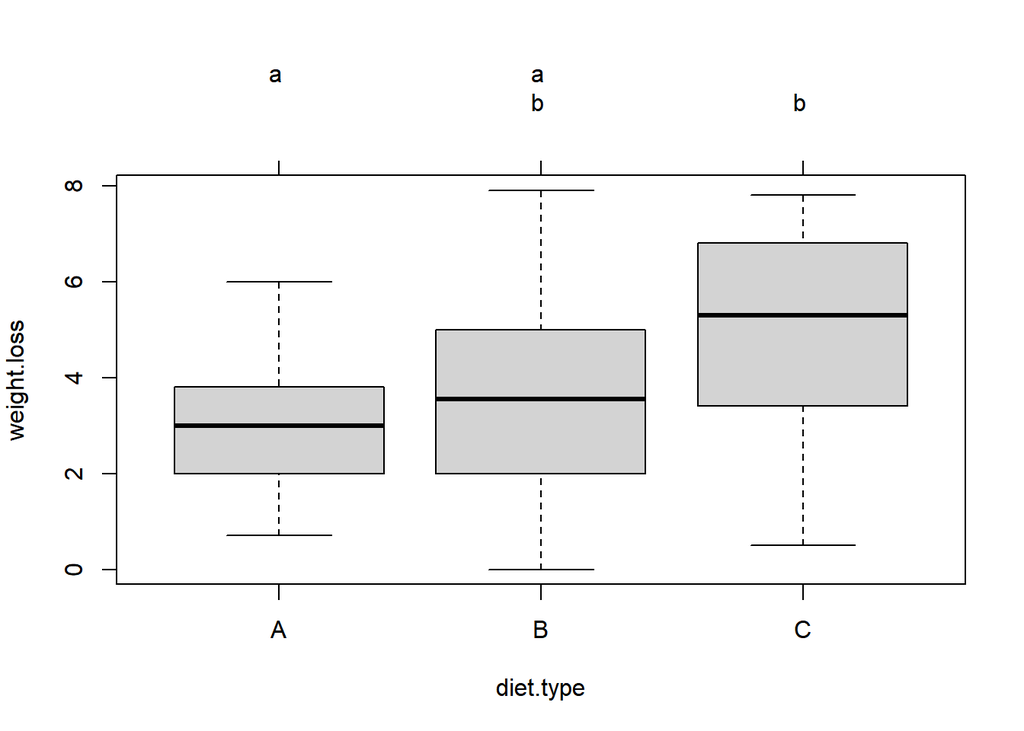

```r
par(mar=c(5,4,6,2))
tuk <- glht(fit, linfct=mcp(diet.type="Tukey"))
plot(cld(tuk, level=.05),col="lightgrey")
```

После удаления выбросов диета B стала эффективнее, чем диета А

Зависимость потери веса от пола

Удалим пустые клетки из нашей выборки, чтобы оптимизировать работу с ней, и присвоим названия мужчинам и женщинам соответственно)

```r
data <- data %>% filter(!is.na(gender))
data$gender <- factor( c('Female', 'Male')[as.ordered(data$gender)] )
summary(data)
```

```
##     gender        age           height      initial.weight  diet.type
##  Female:40   Min.   :16.0   Min.   :141.0   Min.   :58.00   A:21
##  Male  :28   1st Qu.:33.0   1st Qu.:163.0   1st Qu.:65.75   B:22
##              Median :39.5   Median :169.0   Median :72.00   C:25
##              Mean   :39.6   Mean   :170.6   Mean   :71.97
##              3rd Qu.:48.0   3rd Qu.:174.2   3rd Qu.:78.00
##              Max.   :60.0   Max.   :201.0   Max.   :88.00
##   final.weight    weight.loss
##  Min.   :53.00   Min.   :0.500
##  1st Qu.:61.95   1st Qu.:2.475
##  Median :68.60   Median :3.700
##  Mean   :68.01   Mean   :3.959
##  3rd Qu.:73.08   3rd Qu.:5.400
##  Max.   :84.50   Max.   :7.900
```

Проверка на сбалансированность выборки

```r
table(data$gender)
```

```
##
## Female   Male
##     40     28
```

Проверка различия

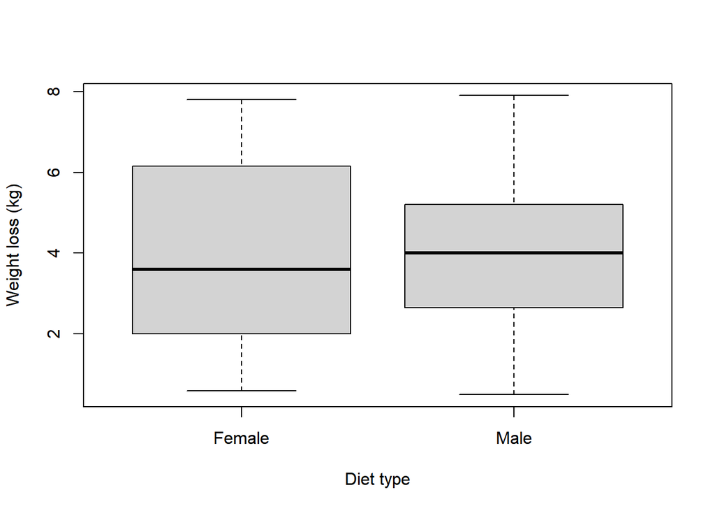

```r
boxplot(weight.loss~gender,data=data,col="light gray",
        ylab = "Weight loss (kg)", xlab = "Diet type")
abline(h=0,col="green")
```

График групповых средних

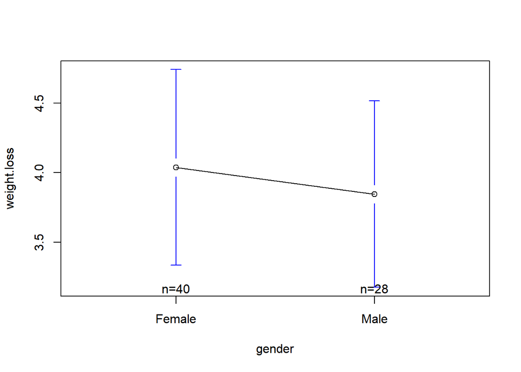

```r
plotmeans(weight.loss ~ gender, data=data)
```

```r
aggregate(data$weight.loss, by = list(data$gender), FUN=sd)
```

```
##   Group.1        x
## 1  Female 2.198914
## 2    Male 1.728087
```

## Моделирование

Для подгонки ANOVA модели используем функцию aov, частный случай линейной модели lm тест на межгрупповые различия

```r
fit <- aov(weight.loss ~ gender, data=data)
summary(fit)
```

```
##             Df Sum Sq Mean Sq F value Pr(>F)
## gender       1    0.6   0.601   0.147  0.702
## Residuals   66  269.2   4.079
```

Попарные различия между средними значениями для всех групп

```r
THSD <- TukeyHSD(fit)
THSD
```

```
##   Tukey multiple comparisons of means
##     95% family-wise confidence level
##
## Fit: aov(formula = weight.loss ~ gender, data = data)
##
## $gender
##                   diff       lwr       upr     p adj
## Male-Female -0.1910714 -1.184638 0.8024954 0.7022449
```

Tukey honest significant differences test)

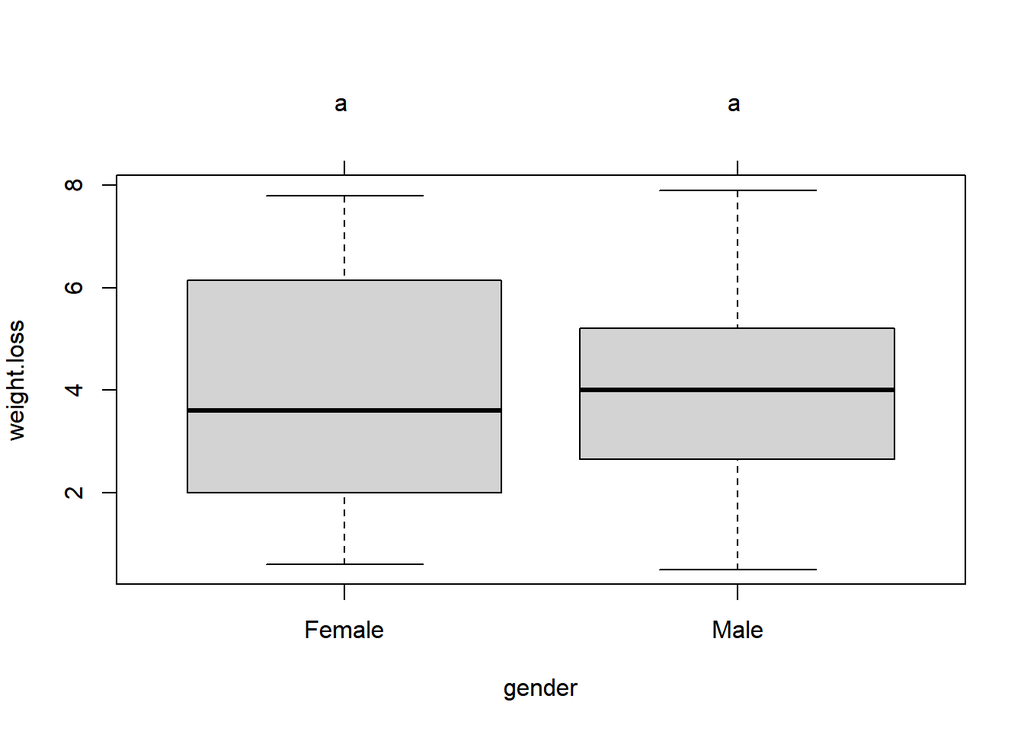

```r
par(mar=c(5,4,6,2))
tuk <- glht(fit, linfct=mcp(gender="Tukey"))
plot(cld(tuk, level=.05),col="lightgrey")
```

Проведя вышепредставленные исследования, мы получили, что потеря веса незначительно зависит от пола, а следовательно худеть всем людям одинаково тяжело.